# ecommerce_data_analysis

### **E-Commerce Data Analysis of Car Company**

```python
import pandas as pd
import matplotlib.pyplot as plt
import numpy as np
import seaborn as sns
import re
```

There are 4 different datasets, with feature are explaned in README file:

- data/cars.csv
- data/sales.csv
- data/users.csv
- data/visits.csv

#### **Users Dataset**

```python
# Load dataset and display
users_df = pd.read_csv("./data/users.csv")
users_df.head()
```

|  | customer_id | user_first_name | user_last_name | gender | email |
| --- | --- | --- | --- | --- | --- |
| 0 | 414970e2-b5c8-43a5-a91b-c5557b9dbec0 | Dwayne | Romero | Male | romero@gmail.com |
| 1 | 504db575-40df-44e1-806d-16777c2dd6e0 | Madison | Burgess | Female | burgess@yahoo.com |
| 2 | 42af527d-454a-465e-9a74-42d4b174a49e | Kristin | Castro | Female | kristin1992@hotmail.com |
| 3 | 38dda2e0-61f6-4d63-9427-f5055c9258ff | Jessica | Taylor | Female | jessica@hotmail.com |
| 4 | 19936993-0480-4399-ab80-9aca3e282d07 | Cody | King | Male | king@hotmail.com |

```python
# Details about users_df
num_entities = users_df.shape[0]
num_columns = users_df.shape[1]
column_names = list(users_df.columns)

print(f"The dataset contains {num_entities} entities, each with {num_columns} attributes.\nThe column names are: {column_names}")
```

```
The dataset contains 138678 entities, each with 5 attributes.
The column names are: ['customer_id', 'user_first_name', 'user_last_name', 'gender', 'email']
```

```python
# The data types in users_df
users_df.dtypes
```

```
customer_id        object
user_first_name    object
user_last_name     object
gender             object
email              object
dtype: object
```

```python
# Check for the presence of null entities
users_df.isna().sum()
```

```
customer_id         554
user_first_name    1798
user_last_name     1756
gender              533
email              1814
dtype: int64
```

```python
# Drop Nan values in customer_id since it is unique and use as id for customers
users_df.dropna(subset=["customer_id"], inplace=True)
users_df.isna().sum()
```

```
customer_id           0
user_first_name    1530
user_last_name     1516
gender              301
email              1581
dtype: int64
```

```python
# Check different categories for gender
users_df["gender"].value_counts()
```

```
gender
Female                      66187
Male                        66025
Other                        5447
data layer field missing      164
Name: count, dtype: int64
```

- We have "data layer field missing" as a value in the gender category.
- We also need to consider this value from the dataset. Investigate customer_id integrity further.

```python
# Replace data layer field missing with Nan
users_df.replace({"data layer field missing": np.nan}, inplace=True)
users_df.isnull().sum()
```

```
customer_id         286
user_first_name    2267
user_last_name     2267
gender              465
email              2366
dtype: int64
```

```python
# Again remove null values in customer_id and conduct futher checks
users_df.dropna(subset=["customer_id"], inplace=True)
users_df.isnull().sum()
```

```
customer_id           0
user_first_name    2084
user_last_name     2081
gender              286
email              2183
dtype: int64
```

```python
# Check customer_id format
customer_id_pattern = r'^[0-9a-f]{8}-[0-9a-f]{4}-[0-9a-f]{4}-[0-9a-f]{4}-[0-9a-f]{12}$'

users_df['customer_id'].astype(str).str.match(customer_id_pattern).all()
```

```
True
```

- Now, we are sure that all customer_id patterns are valid

```python
# Check gender categories again
gender = users_df["gender"].value_counts()
gender
```

```
gender
Female    66141
Male      65972
Other      5439
Name: count, dtype: int64
```

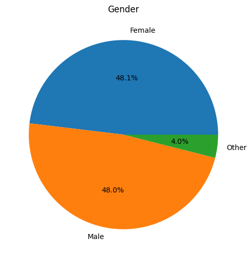

```python
# Plot gender distribution for better understanding
plt.figure(figsize=(6,6))

gender.plot(kind="pie", autopct="%1.1f%%")

plt.title("Gender")
plt.ylabel("")
plt.show()
```

##### **Take-1**

The distribution of gender is similar, with

- Males comprising 65,972 (48.0%)
- Females comprising 66,141 (48.1%)
- Others comprising 5,439 (4.0%).

#### **Cars Dataset**

```python
# Load dataset and display
cars_df = pd.read_csv("./data/cars.csv")
cars_df.head()
```

|  | car_id | car_model | fuel_type | release_date | price |
| --- | --- | --- | --- | --- | --- |
| 0 | 2c192c40-f69f-42e5-9431-41d92558568b | Sierra | Diesel | 2013-05-01 | 35000 |
| 1 | d2e63c70-e732-4299-bb0c-ba00b875a4bd | 3 Series | Diesel | 2014-12-11 | 40000 |
| 2 | 00b0c76e-9f2f-41c1-8324-38fbe9c2a8aa | Model i8 | Electric | 2019-01-01 | 145000 |
| 3 | 4abc60d6-73cb-44df-8bde-d8f5936bbdfb | Coupe | Gasoline | 2015-08-01 | 65000 |
| 4 | 5fae80e1-82d6-45d3-8512-7db7bb32d5bd | Sedan | Gasoline | 2018-07-15 | 45000 |

```python
# Details about cars_df
num_entities = cars_df.shape[0]
num_columns = cars_df.shape[1]
column_names = list(cars_df.columns)

print(f"The dataset contains {num_entities} entities, each with {num_columns} attributes.\nThe column names are: {column_names}")
```

```
The dataset contains 12 entities, each with 5 attributes.
The column names are: ['car_id', 'car_model', 'fuel_type', 'release_date', 'price']
```

```python
# The data types in cars_df
cars_df.dtypes
```

```
car_id          object
car_model       object
fuel_type       object
release_date    object
price            int64
dtype: object
```

```python
# Convert 'release_date' to datetime type
cars_df['release_date'] = pd.to_datetime(cars_df['release_date'])
cars_df.dtypes
```

```
car_id                  object
car_model               object
fuel_type               object
release_date    datetime64[ns]
price                    int64
dtype: object
```

```python
# Check for the presence of null entities
cars_df.isna().sum()
```

```
car_id          0
car_model       0
fuel_type       0
release_date    0
price           0
dtype: int64
```

##### **Take-1**

There are no null entries in the cars_df dataframe.

```python
# Identify the different values and counts for "fuel_type"
fuel_types = cars_df["fuel_type"].value_counts()
fuel_types
```

```
fuel_type
Gasoline    5
Electric    4
Diesel      3
Name: count, dtype: int64
```

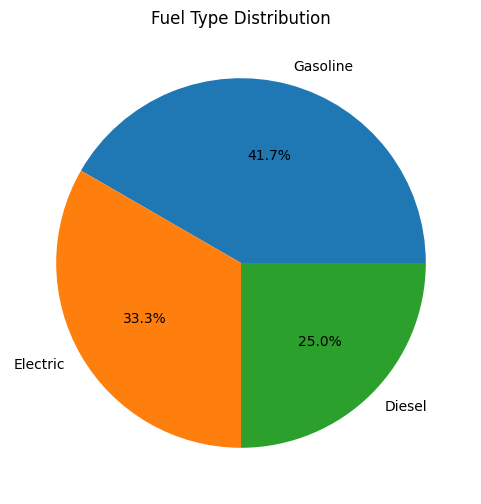

```python
# Plot the distribution of "fuel_type" for better understanding
plt.figure(figsize=(6,6))

fuel_types.plot(kind="pie", autopct="%1.1f%%")

plt.title('Fuel Type Distribution')
plt.ylabel('')
plt.show()
```

##### **Take-2**

There are 3 different fuel types

```python
# Look for the average release_date for each fuel_type
for fuel_type in cars_df["fuel_type"].unique():
    avg_release_date = cars_df[cars_df["fuel_type"]==fuel_type]["release_date"].dt.year.mean()
    print(f"Average release date for {fuel_type}: {avg_release_date}")
```

```
Average release date for Diesel: 2012.3333333333333
Average release date for Electric: 2016.25
Average release date for Gasoline: 2017.0
```

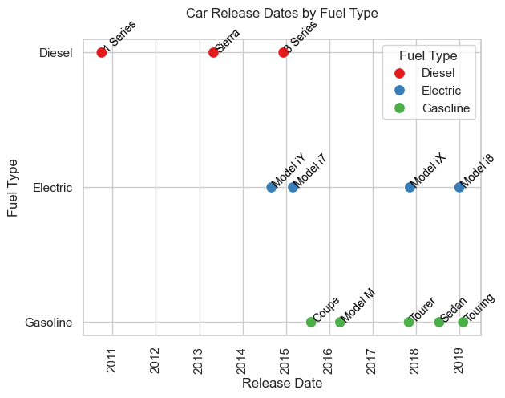

```python
# Investigate car_model release_date respect to fuel_type
sns.set(style="whitegrid")

sns.scatterplot(data=cars_df, x='release_date', y='fuel_type', hue='fuel_type', palette='Set1', s=100)

for line in range(0, cars_df.shape[0]):
    plt.text(
        cars_df.release_date[line],
        cars_df.fuel_type[line],
        cars_df.car_model[line],
        horizontalalignment='left',
        size='small',
        color='black',
        rotation=45
    )

plt.title('Car Release Dates by Fuel Type', y=1.05)
plt.xlabel('Release Date')
plt.ylabel('Fuel Type')

plt.xticks(rotation=90)
plt.legend(title='Fuel Type')
plt.show()
```

##### **Take-3**

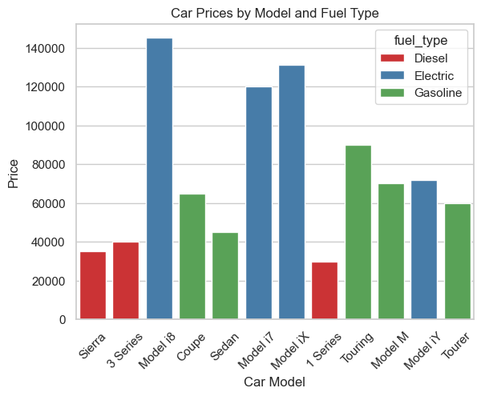

```python
# Investigate car_model and price
sns.set(style="whitegrid")

sns.barplot(data=cars_df, x='car_model', y='price', hue='fuel_type', palette='Set1')

plt.title('Car Prices by Model and Fuel Type')
plt.xlabel('Car Model')
plt.ylabel('Price')

plt.xticks(rotation=45)
plt.show()
```

```python
# Invetigate fuel_type and price
fuel_type_price = cars_df.groupby(by="fuel_type")["price"].mean()
fuel_type_price
```

```
fuel_type
Diesel       35000.0
Electric    117000.0
Gasoline     66000.0
Name: price, dtype: float64
```

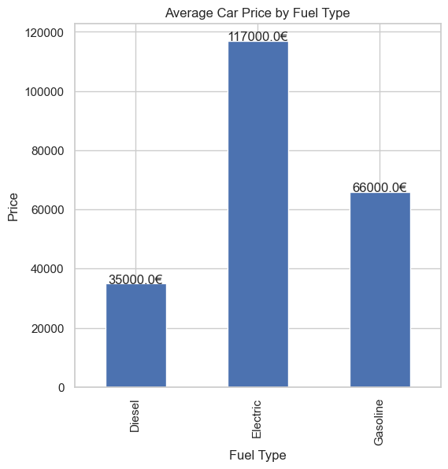

```python
# Plot average price by fuel_type for better understanding
plt.figure(figsize=(6,6))

fuel_type_price.plot(kind="bar")

plt.title("Average Car Price by Fuel Type")
plt.xlabel("Fuel Type")
plt.ylabel("Price")

for index, value in enumerate(fuel_type_price):
    plt.text(index, value + 20, str(round(value, 2))+"€", ha='center')

plt.show()
```

##### **Take-4**

The electric models are significantly more expensive compared to diesel and gasoline models, with an average car price of €117,000, while diesel and gasoline have average prices of €35,000 and €66,000, respectively.

#### **Visits Dataset**

```python
# Load dataset and display
visits_df = pd.read_csv("./data/visits.csv")
visits_df.head()
```

|  | visit_id | customer_id | start_timestamp | end_timestamp | visit_type | transaction_id |
| --- | --- | --- | --- | --- | --- | --- |
| 0 | 7f94232d-9cca-4893-aebe-9a267a752f87 | de5323eb-5e01-481f-b73a-bb78af953894 | 2023-04-18 10:51:24.477465 | 2023-04-18 11:46:26.893492 | car configuration | NaN |
| 1 | dcb32330-15b0-4fd1-b376-9b9335fee7f9 | 15dcef30-b549-447b-8809-229c9de8526b | 2021-03-03 17:54:25.117599 | 2021-03-03 18:07:25.117599 | viewing | NaN |
| 2 | 8b02d675-1365-45bc-af64-61ef9e79149c | 3b656455-1690-47d9-b7ad-9e0aaa3bb229 | 2023-07-07 13:09:00.000000 | 2023-07-07 13:19:00.000000 | purchasing | d1bfe5f5-edc1-4148-8eb0-8127dd3b52c1 |
| 3 | bdfc7048-adc5-4da7-a37a-4f9d90cf6436 | c583c671-2f8a-47f3-9460-bd444b1811c8 | 2023-09-14 11:25:12.820271 | 2023-09-14 12:20:15.523626 | car configuration | NaN |
| 4 | 2ad3a1e1-0b9c-417f-95f7-70607b0fe96e | da8268d8-4e81-4538-bf1d-836ac4d5b155 | 2020-12-04 19:15:41.833927 | 2020-12-04 19:27:41.833927 | car configuration | NaN |

```python
# Details about visits_df
num_entities = visits_df.shape[0]
num_columns = visits_df.shape[1]
column_names = list(visits_df.columns)

print(f"The dataset contains {num_entities} entities, each with {num_columns} attributes.\nThe column names are: {column_names}")
```

```
The dataset contains 438587 entities, each with 6 attributes.
The column names are: ['visit_id', 'customer_id', 'start_timestamp', 'end_timestamp', 'visit_type', 'transaction_id']
```

```python
# The data types in visits_df
visits_df.dtypes
```

```
visit_id           object
customer_id        object
start_timestamp    object
end_timestamp      object
visit_type         object
transaction_id     object
dtype: object
```

```python
# Convert timestamp data type to datetime obj
visits_df[["start_timestamp","end_timestamp"]] = visits_df[["start_timestamp","end_timestamp"]].apply(lambda x:pd.to_datetime(x))
visits_df.dtypes
```

```
visit_id                   object
customer_id                object
start_timestamp    datetime64[ns]
end_timestamp      datetime64[ns]
visit_type                 object
transaction_id             object
dtype: object
```

```python
# Check for the presence of null entities
visits_df.isnull().sum()
```

```
visit_id                0
customer_id             0
start_timestamp         0
end_timestamp           0
visit_type              0
transaction_id     363807
dtype: int64
```

```python
# Sanity Check: All visit_id' unique
len(visits_df["visit_id"].unique())
```

```
438587
```

```python
# Check validity of visit_id
visit_id_pattern = r'^[0-9a-f]{8}-[0-9a-f]{4}-[0-9a-f]{4}-[0-9a-f]{4}-[0-9a-f]{12}$'

visits_df['visit_id'].astype(str).str.match(visit_id_pattern).all()
```

```
True
```

- There are no null visit_id values, furthermore, all values in visit_id conform to the specified pattern.

```python
# Create a new column "visit_duration_min" which can be utilized in the future for further data analysis.
visits_df['visit_duration_min'] = (visits_df['end_timestamp'] - visits_df['start_timestamp']).dt.total_seconds() / 60
visits_df.head()
```

|  | visit_id | customer_id | start_timestamp | end_timestamp | visit_type | transaction_id | visit_duration_min |
| --- | --- | --- | --- | --- | --- | --- | --- |
| 0 | 7f94232d-9cca-4893-aebe-9a267a752f87 | de5323eb-5e01-481f-b73a-bb78af953894 | 2023-04-18 10:51:24.477465 | 2023-04-18 11:46:26.893492 | car configuration | NaN | 55.040267 |
| 1 | dcb32330-15b0-4fd1-b376-9b9335fee7f9 | 15dcef30-b549-447b-8809-229c9de8526b | 2021-03-03 17:54:25.117599 | 2021-03-03 18:07:25.117599 | viewing | NaN | 13.000000 |
| 2 | 8b02d675-1365-45bc-af64-61ef9e79149c | 3b656455-1690-47d9-b7ad-9e0aaa3bb229 | 2023-07-07 13:09:00.000000 | 2023-07-07 13:19:00.000000 | purchasing | d1bfe5f5-edc1-4148-8eb0-8127dd3b52c1 | 10.000000 |
| 3 | bdfc7048-adc5-4da7-a37a-4f9d90cf6436 | c583c671-2f8a-47f3-9460-bd444b1811c8 | 2023-09-14 11:25:12.820271 | 2023-09-14 12:20:15.523626 | car configuration | NaN | 55.045056 |
| 4 | 2ad3a1e1-0b9c-417f-95f7-70607b0fe96e | da8268d8-4e81-4538-bf1d-836ac4d5b155 | 2020-12-04 19:15:41.833927 | 2020-12-04 19:27:41.833927 | car configuration | NaN | 12.000000 |

- It is important to check the first and last visits because some of the car models could be outside of this span.

```python
# Investigate first visit and last visit
print("First visit: ", visits_df["start_timestamp"].min())
print("Last visit:", visits_df["start_timestamp"].max())
```

```
First visit:  2020-06-25 01:00:00
Last visit: 2024-01-30 23:00:00
```

##### **Take-1**

- Now, we are sure that all car_models were released before the visit data records.

```python
# Determine average duration of visits
print("Average duration of visit:", visits_df["visit_duration_min"].mean().round(2), "minutes")
```

```
Average duration of visit: 31.84 minutes
```

```python
# Identify the different values and counts for "visit_type"
visit_types = visits_df["visit_type"].value_counts()
visit_types
```

```
visit_type
viewing              211888
testing               80880
purchasing            74780
car configuration     71039
Name: count, dtype: int64
```

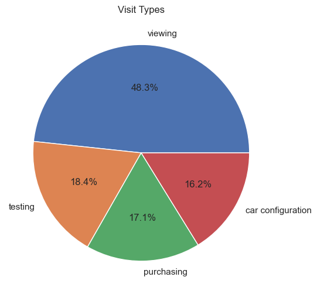

```python
# Plot the distribution of "visit_type" for better understanding
plt.figure(figsize=(6,6))
visit_types.plot(kind="pie", autopct='%1.1f%%')

plt.title('Visit Types')
plt.ylabel("")
plt.show()
```

```python
# Investigate average duration by different visit_type
mean_durations = visits_df.groupby('visit_type')['visit_duration_min'].mean()
mean_durations
```

```
visit_type
car configuration    35.474036
purchasing           14.496817
testing              49.044696
viewing              30.184230
Name: visit_duration_min, dtype: float64
```

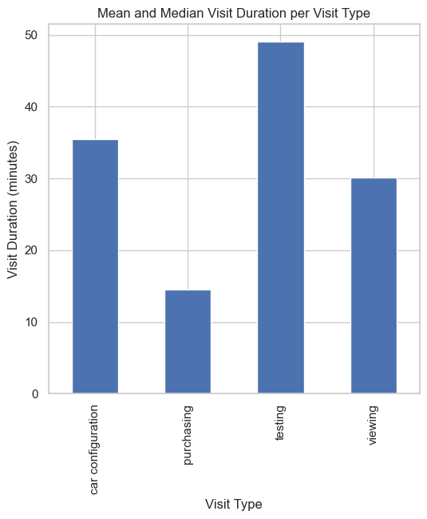

```python
# Plot
plt.figure(figsize=(6, 6))

mean_durations.plot(kind='bar')

plt.title('Mean and Median Visit Duration per Visit Type')
plt.xlabel('Visit Type')
plt.ylabel('Visit Duration (minutes)')

plt.show()
```

##### **Take-2**

There are 4 distinct visit types:

1. Viewing with 211,888 visits (48.3%)
2. Purchasing with 74,780 visits (17.1%)
3. Testing with 80,880 visits (18.4%)
4. Car Configuration with 71,039 visits (16.2%)
- The average time spent for visits is 31.84 minutes.
- Testing takes the greatest time, while purchasing takes the least time.

With different types of visits:

1. Viewing: 30.18 minutes
2. Purchasing: 14.50 minutes
3. Testing: 49.04 minutes
4. Car Configuration: 35.48 minutes

```python
# The number of distinct interactions with the website for each customer
visit_counts = visits_df.groupby(by="customer_id").count()["visit_id"].value_counts()
visit_counts = visit_counts.sort_index()
visit_counts
```

```
visit_id
1     35482
2     26948
3     20939
4     18230
5     14187
6      9202
7      5273
8      3684
9      1593
10      470
11      129
12       30
13        5
14        1
15        2
17        1
Name: count, dtype: int64
```

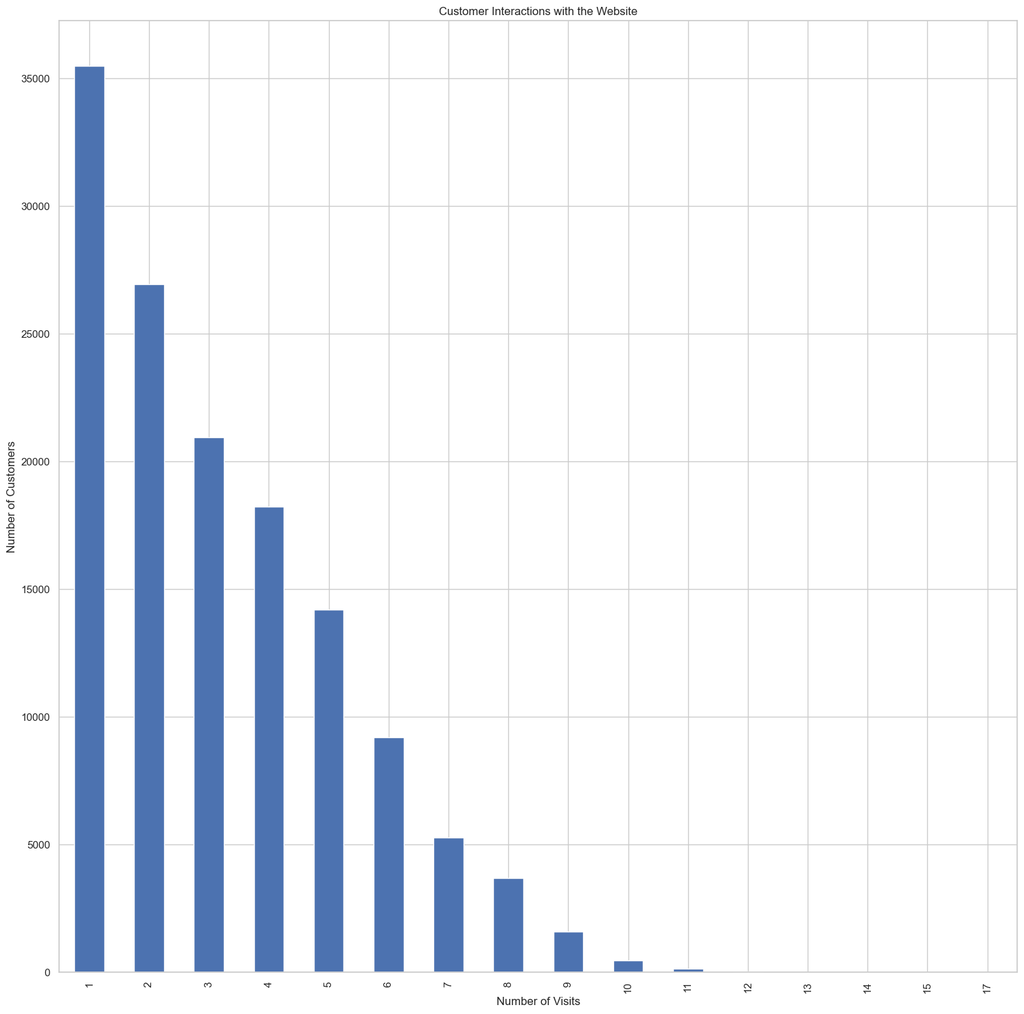

```python
# Plot
plt.figure(figsize=(18, 18))
visit_counts.plot(kind='bar')

plt.title('Customer Interactions with the Website')
plt.xlabel('Number of Visits')
plt.ylabel('Number of Customers')

plt.show()
```

##### **Take-3**

The most of the customer interected with following

- 35482 customers interacted with website 1 time.
- 26948 customers interacted with website 2 times
- 20939 customers interacted with website 3 times ... ... ...
- 1 customer interacted with website 17 times.

```python
# Investigate how interaction to website changes across time
visit_trend = visits_df.set_index('start_timestamp')

quarterly_counts = visit_trend.resample('Q').count()
quarterly_counts.index = quarterly_counts.index.to_period('Q')
quarterly_counts
```

| start_timestamp | visit_id | customer_id | end_timestamp | visit_type | transaction_id | visit_duration_min |
| --- | --- | --- | --- | --- | --- | --- |
| 2020Q2 | 193 | 193 | 193 | 193 | 0 | 193 |
| 2020Q3 | 12202 | 12202 | 12202 | 12202 | 1734 | 12202 |
| 2020Q4 | 18960 | 18960 | 18960 | 18960 | 4017 | 18960 |
| 2021Q1 | 20336 | 20336 | 20336 | 20336 | 4242 | 20336 |
| 2021Q2 | 22397 | 22397 | 22397 | 22397 | 4621 | 22397 |
| 2021Q3 | 23988 | 23988 | 23988 | 23988 | 4782 | 23988 |
| 2021Q4 | 26298 | 26298 | 26298 | 26298 | 5179 | 26298 |
| 2022Q1 | 26911 | 26911 | 26911 | 26911 | 5145 | 26911 |
| 2022Q2 | 29784 | 29784 | 29784 | 29784 | 5445 | 29784 |
| 2022Q3 | 31771 | 31771 | 31771 | 31771 | 5702 | 31771 |
| 2022Q4 | 34303 | 34303 | 34303 | 34303 | 6003 | 34303 |
| 2023Q1 | 36217 | 36217 | 36217 | 36217 | 5933 | 36217 |
| 2023Q2 | 39857 | 39857 | 39857 | 39857 | 6307 | 39857 |
| 2023Q3 | 44556 | 44556 | 44556 | 44556 | 6493 | 44556 |
| 2023Q4 | 52373 | 52373 | 52373 | 52373 | 6919 | 52373 |
| 2024Q1 | 18441 | 18441 | 18441 | 18441 | 2258 | 18441 |

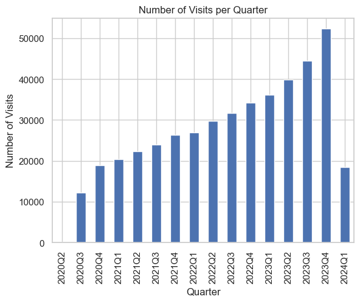

```python
# Plot
fig, ax = plt.subplots()
quarterly_counts["visit_id"].plot(kind='bar', legend=False, ax=ax)
ax.set_xticklabels([str(period) for period in quarterly_counts.index])

plt.title('Number of Visits per Quarter')
plt.xlabel('Quarter')
plt.ylabel('Number of Visits')
plt.xticks(rotation=90)

plt.show()
```

```python
# Also include visit_type
quarterly_counts_visit_type = visit_trend.groupby([pd.Grouper(freq='Q'), 'visit_type']).size().unstack(fill_value=0)
quarterly_counts_visit_type.index = quarterly_counts_visit_type.index.to_period('Q')
quarterly_counts_visit_type
```

| visit_type start_timestamp | car configuration | purchasing | testing | viewing |
| --- | --- | --- | --- | --- |
| 2020Q2 | 4 | 0 | 177 | 12 |
| 2020Q3 | 850 | 1734 | 4702 | 4916 |
| 2020Q4 | 1546 | 4017 | 5593 | 7804 |
| 2021Q1 | 2012 | 4242 | 5438 | 8644 |
| 2021Q2 | 2355 | 4621 | 5616 | 9805 |
| 2021Q3 | 2918 | 4782 | 5566 | 10722 |
| 2021Q4 | 3248 | 5179 | 5695 | 12176 |
| 2022Q1 | 3626 | 5145 | 5699 | 12441 |
| 2022Q2 | 4378 | 5445 | 5797 | 14164 |
| 2022Q3 | 5038 | 5702 | 5798 | 15233 |
| 2022Q4 | 5638 | 6003 | 5980 | 16682 |
| 2023Q1 | 6271 | 5933 | 5883 | 18130 |
| 2023Q2 | 7623 | 6307 | 5814 | 20113 |
| 2023Q3 | 8906 | 6493 | 5938 | 23219 |
| 2023Q4 | 11674 | 6919 | 5910 | 27870 |
| 2024Q1 | 4952 | 2258 | 1274 | 9957 |

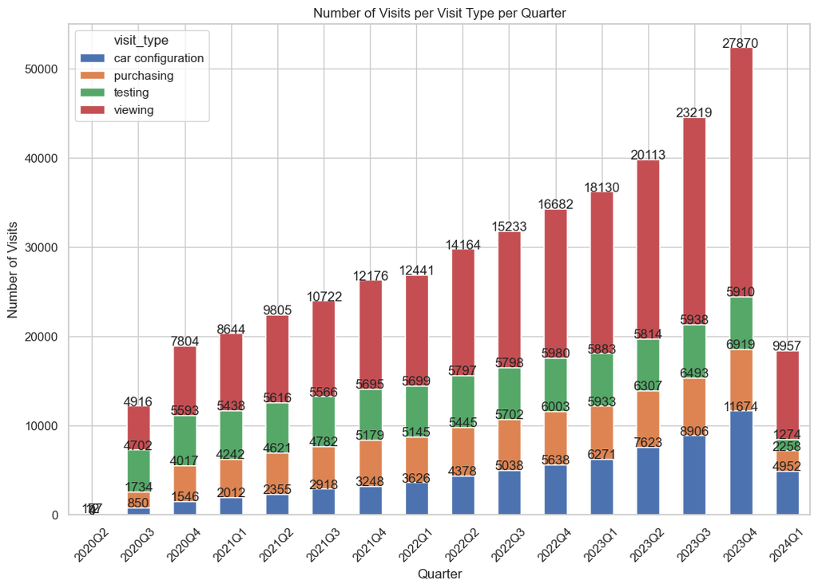

```python
# Plot
fig, ax = plt.subplots(figsize=(12, 8))

quarterly_counts_visit_type.plot(kind='bar', stacked=True, ax=ax)

ax.set_xticklabels([str(period) for period in quarterly_counts_visit_type.index])

# Add counts on top of the bars
for p in ax.patches:
    width, height = p.get_width(), p.get_height()
    x, y = p.get_xy()
    ax.annotate(f'{int(height)}', (x + width / 2, y + height + 10), ha='center')

plt.title('Number of Visits per Visit Type per Quarter')
plt.xlabel('Quarter')
plt.ylabel('Number of Visits')
plt.xticks(rotation=45)

plt.show()
```

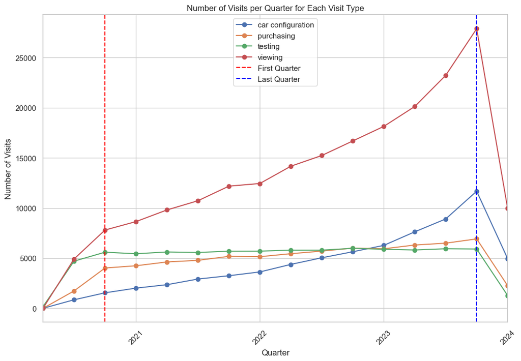

```python
# Plot individually
fig, ax = plt.subplots(figsize=(12, 8))

# Loop through each visit type
for visit_type in quarterly_counts_visit_type.columns:
    visit_type_data = quarterly_counts_visit_type[visit_type]
    visit_type_data.plot(marker='o', label=visit_type)

first_quarter = quarterly_counts_visit_type.index[2]
last_quarter = quarterly_counts_visit_type.index[-2]
ax.axvline(x=first_quarter, color='red', linestyle='--', label='First Quarter')
ax.axvline(x=last_quarter, color='blue', linestyle='--', label='Last Quarter')

plt.title('Number of Visits per Quarter for Each Visit Type')
plt.xlabel('Quarter')
plt.ylabel('Number of Visits')
plt.legend()
plt.xticks(rotation=45)
plt.grid(True)

plt.show()
```

##### **Take-4**

- As time passes, the number of interactions on the website significantly increases.
- This increase is driven by visit types "viewing" and "car configuration".

```python
# Investigate average minutes spend respect visit_type across time
quarterly_avg_duration = visits_df.set_index('start_timestamp')
quarterly_avg_duration = quarterly_avg_duration.groupby([pd.Grouper(freq='Q'), 'visit_type'])['visit_duration_min'].mean().unstack(fill_value=0)
quarterly_avg_duration
```

| visit_type start_timestamp | car configuration | purchasing | testing | viewing |
| --- | --- | --- | --- | --- |
| 2020-06-30 | 7.250000 | 0.000000 | 65.485876 | 27.694162 |
| 2020-09-30 | 13.968538 | 14.292388 | 52.281157 | 21.000196 |
| 2020-12-31 | 17.059809 | 14.489420 | 49.160558 | 21.170785 |
| 2021-03-31 | 19.415564 | 14.464875 | 49.270504 | 21.396595 |
| 2021-06-30 | 23.454789 | 14.444276 | 49.434295 | 22.026812 |
| 2021-09-30 | 25.226776 | 14.609578 | 49.885555 | 23.555650 |
| 2021-12-31 | 27.995269 | 14.663449 | 49.012994 | 24.371938 |
| 2022-03-31 | 29.547520 | 14.408941 | 48.408668 | 25.712087 |
| 2022-06-30 | 31.001657 | 14.331497 | 48.208729 | 26.717320 |
| 2022-09-30 | 32.485610 | 14.560505 | 48.791652 | 28.098776 |
| 2022-12-31 | 34.531019 | 14.386307 | 47.803679 | 29.262383 |
| 2023-03-31 | 35.844097 | 14.505141 | 48.307836 | 30.724222 |
| 2023-06-30 | 37.760472 | 14.544474 | 47.929137 | 32.295035 |
| 2023-09-30 | 39.266686 | 14.506854 | 47.954867 | 34.742961 |
| 2023-12-31 | 42.917912 | 14.562075 | 48.368528 | 37.780693 |
| 2024-03-31 | 52.170965 | 14.561559 | 58.429356 | 49.807348 |

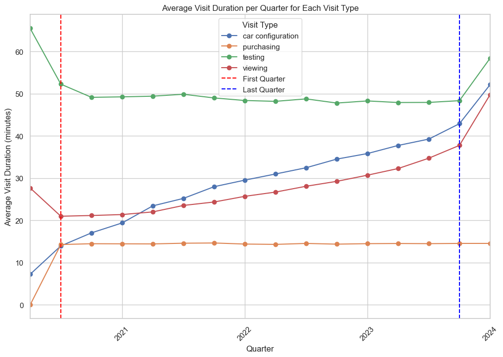

```python
# Plot
fig, ax = plt.subplots(figsize=(12, 8))

for visit_type in quarterly_avg_duration.columns:
    visit_type_data = quarterly_avg_duration[visit_type]
    visit_type_data.plot(marker='o', label=visit_type)

first_quarter = quarterly_avg_duration.index[1]
last_quarter = quarterly_avg_duration.index[-2]
ax.axvline(x=first_quarter, color='red', linestyle='--', label='First Quarter')
ax.axvline(x=last_quarter, color='blue', linestyle='--', label='Last Quarter')

plt.title('Average Visit Duration per Quarter for Each Visit Type')
plt.xlabel('Quarter')
plt.ylabel('Average Visit Duration (minutes)')
plt.legend(title='Visit Type')
plt.xticks(rotation=45)
plt.grid(True)

plt.show()
```

##### **Take-5**

- As time passes, the average duration of interaction does not change over time for purchase and testing visit types.
- One possible explanation for this phenomenon could be that these interaction types involve user-filled information (such as personal data, card information, etc.), which takes a similar amount of time across different periods.
- On the other hand, we observe an increase in the average time spent on visit types "viewing" and "car configuration." This may be related to additional options or features added to the website, leading to more time spent on the site.

```python
# What is the trend for website adoption by new users
new_customers = visits_df.groupby('customer_id')['start_timestamp'].min().reset_index()
new_customers.set_index('start_timestamp', inplace=True)

new_customers_per_quarter = new_customers.resample('Q')['customer_id'].nunique()
new_customers_per_quarter.index = new_customers_per_quarter.index.to_period('Q')
new_customers_per_quarter
```

```
start_timestamp
2020Q2      190
2020Q3     5745
2020Q4     6867
2021Q1     7102
2021Q2     7681
2021Q3     8243
2021Q4     8975
2022Q1     9177
2022Q2     9987
2022Q3    10546
2022Q4    10894
2023Q1    11115
2023Q2    11574
2023Q3    11908
2023Q4    12352
2024Q1     3820
Freq: Q-DEC, Name: customer_id, dtype: int64
```

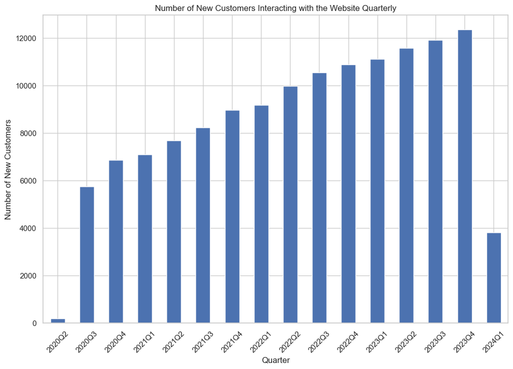

```python
# Plot
fig, ax = plt.subplots(figsize=(12, 8))
new_customers_per_quarter.plot(kind='bar', ax=ax)

ax.set_xticklabels([str(period) for period in new_customers_per_quarter.index])

plt.title('Number of New Customers Interacting with the Website Quarterly')
plt.xlabel('Quarter')
plt.ylabel('Number of New Customers')
plt.xticks(rotation=45)
plt.grid(True)

plt.show()
```

```python
# Investigate new user' visit type
new_customer_visit_type = visits_df.sort_values('start_timestamp').groupby('customer_id').first().reset_index()
new_customer_visit_type.set_index('start_timestamp', inplace=True)
new_customer_visit_type = new_customer_visit_type.groupby([pd.Grouper(freq='Q'), 'visit_type'])['customer_id'].nunique().unstack(fill_value=0)

new_customer_visit_type
```

| visit_type start_timestamp | car configuration | purchasing | testing | viewing |
| --- | --- | --- | --- | --- |
| 2020-06-30 | 4 | 0 | 175 | 11 |
| 2020-09-30 | 409 | 116 | 3097 | 2123 |
| 2020-12-31 | 723 | 299 | 2711 | 3134 |
| 2021-03-31 | 993 | 302 | 2190 | 3617 |
| 2021-06-30 | 1253 | 364 | 1887 | 4177 |
| 2021-09-30 | 1582 | 311 | 1632 | 4718 |
| 2021-12-31 | 1763 | 357 | 1541 | 5314 |
| 2022-03-31 | 1910 | 365 | 1353 | 5549 |
| 2022-06-30 | 2259 | 331 | 1289 | 6108 |
| 2022-09-30 | 2506 | 340 | 1233 | 6467 |
| 2022-12-31 | 2630 | 344 | 1218 | 6702 |
| 2023-03-31 | 2689 | 331 | 1115 | 6980 |
| 2023-06-30 | 3069 | 341 | 1038 | 7126 |
| 2023-09-30 | 3103 | 320 | 977 | 7508 |
| 2023-12-31 | 3482 | 307 | 878 | 7685 |
| 2024-03-31 | 1215 | 99 | 98 | 2408 |

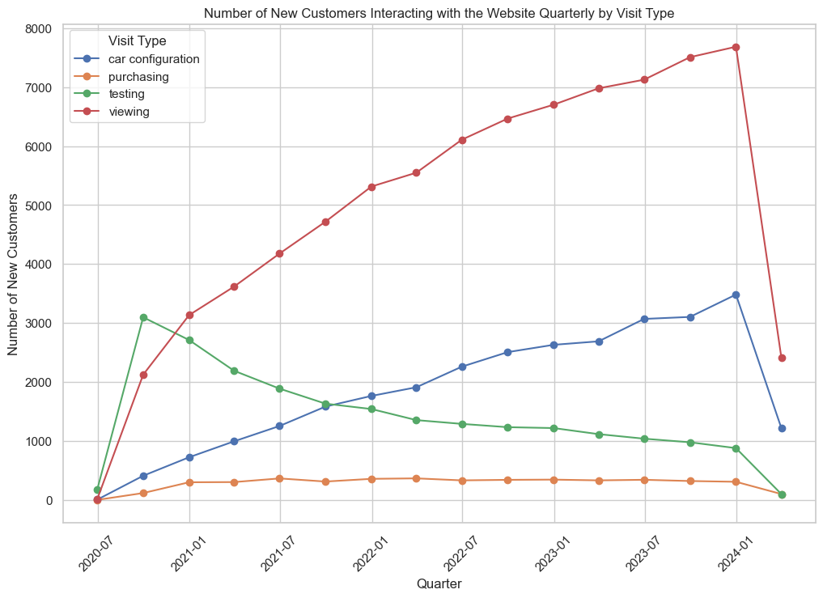

```python
# Plot
fig, ax = plt.subplots(figsize=(12, 8))

for visit_type in new_customer_visit_type.columns:
    ax.plot(new_customer_visit_type.index, new_customer_visit_type[visit_type], marker='o', label=visit_type)

plt.title('Number of New Customers Interacting with the Website Quarterly by Visit Type')
plt.xlabel('Quarter')
plt.ylabel('Number of New Customers')
plt.xticks(rotation=45)
plt.legend(title='Visit Type')
plt.grid(True)

plt.show()
```

##### **Take-6**

- When comparing the previously generated "Number of Visits per Quarter for Each Visit Type," the increase rate of "viewing" and "car configuration" visit types is higher for new customers.
- On the other hand, the "testing" visit type is slightly decreasing over time. This differs from the "Number of Visits per Quarter for Each Visit Type" plot, where testing follows a relatively consistent trend over time. In this plot, it decreases over time.
- Additionally, it's worth noting that although the "purchase" visit type follows a similar trend, overall interaction is significantly lower.

```python
# Identify visit patterns that leads to purchase
visits_df = visits_df.sort_values(by=['customer_id', 'start_timestamp'])

visits_df['is_purchase'] = visits_df['visit_type'] == 'purchasing'
visits_df['interaction_count'] = visits_df.groupby('customer_id').cumcount() + 1

first_purchase_times = visits_df[visits_df['is_purchase']].groupby('customer_id')['start_timestamp'].min().reset_index()
first_purchase_times.columns = ['customer_id', 'first_purchase_time']

visits_df = visits_df.merge(first_purchase_times, on='customer_id', how='left')

# Filter out interactions that occurred after the first purchase
visits_df_before_purchase = visits_df[visits_df['start_timestamp'] <= visits_df['first_purchase_time']]

visit_type_sequences = visits_df_before_purchase.groupby('customer_id')['visit_type'].apply(list).reset_index()

purchase_times = visits_df[visits_df['is_purchase']].groupby('customer_id')['start_timestamp'].min().reset_index()
purchase_times.columns = ['customer_id', 'purchase_time']

interaction_sequences_df = visit_type_sequences.merge(purchase_times, on='customer_id')
interaction_sequences_df['interaction_count'] = interaction_sequences_df['visit_type'].apply(len)
interaction_sequences_df.head()
```

|  | customer_id | visit_type | purchase_time | interaction_count |
| --- | --- | --- | --- | --- |
| 0 | 00018dda-2d4b-4abb-8629-98a9063a5cba | [viewing, viewing, purchasing] | 2021-05-27 14:17:00 | 3 |
| 1 | 0001efdb-9ec2-4a1e-afed-88c7dee53e15 | [viewing, viewing, testing, purchasing] | 2022-06-19 09:05:00 | 4 |
| 2 | 00025afa-8bb4-41da-808b-4d31a09d8768 | [viewing, viewing, purchasing] | 2022-12-11 14:18:00 | 3 |
| 3 | 00039e36-b5c3-4019-82ca-b6891f1b3198 | [viewing, testing, purchasing] | 2022-04-01 14:46:00 | 3 |
| 4 | 00051014-7e4b-43d7-b6ce-18f1bd50aabd | [testing, viewing, viewing, viewing, testing, ... | 2022-03-28 14:28:00 | 6 |

```python
# The number of visit that lead to purchase
interaction_count = interaction_sequences_df.groupby("interaction_count")["customer_id"].count()
interaction_count
```

```
interaction_count
1      4527
2     12570
3     17663
4     16498
5     11706
6      6705
7      3184
8      1272
9       430
10      173
11       34
12        8
13        3
15        1
Name: customer_id, dtype: int64
```

```python
print(f"Mean of the number of days from the first interaction to the first purchase: {interaction_sequences_df['interaction_count'].mean()}")
print(f"Median of the number of days from the first interaction to the first purchase: {interaction_sequences_df['interaction_count'].median()}")
```

```
Mean of the number of days from the first interaction to the first purchase: 3.8248054136464544
Median of the number of days from the first interaction to the first purchase: 4.0
```

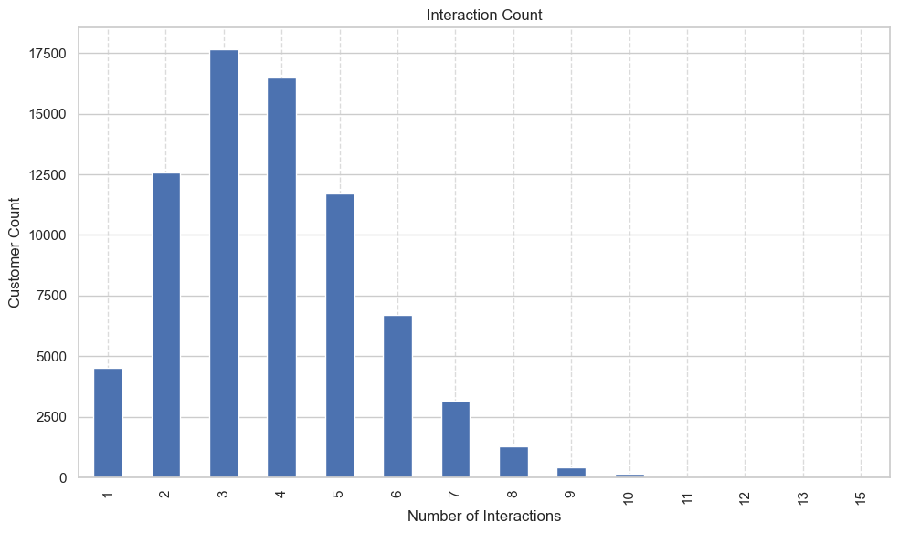

```python
# Plot
plt.figure(figsize=(10, 6))

interaction_count.plot(kind='bar')

plt.title('Interaction Count')
plt.xlabel('Number of Interactions')
plt.ylabel('Customer Count')
plt.grid(axis='x', linestyle='--', alpha=0.7)
plt.tight_layout()
plt.show()
```

```python
# Calculate the number of days from the first interaction to the first purchase
visits_df['days_to_purchase'] = (visits_df['first_purchase_time'] - visits_df['start_timestamp']).dt.days

interaction_sequences_df = interaction_sequences_df.merge(
    visits_df[['customer_id', 'days_to_purchase']].drop_duplicates(subset='customer_id'),
    on='customer_id',
    how='left'
)
interaction_sequences_df.head()
```

|  | customer_id | visit_type | purchase_time | interaction_count | days_to_purchase |
| --- | --- | --- | --- | --- | --- |
| 0 | 00018dda-2d4b-4abb-8629-98a9063a5cba | [viewing, viewing, purchasing] | 2021-05-27 14:17:00 | 3 | 36.0 |
| 1 | 0001efdb-9ec2-4a1e-afed-88c7dee53e15 | [viewing, viewing, testing, purchasing] | 2022-06-19 09:05:00 | 4 | 35.0 |
| 2 | 00025afa-8bb4-41da-808b-4d31a09d8768 | [viewing, viewing, purchasing] | 2022-12-11 14:18:00 | 3 | 28.0 |
| 3 | 00039e36-b5c3-4019-82ca-b6891f1b3198 | [viewing, testing, purchasing] | 2022-04-01 14:46:00 | 3 | 31.0 |
| 4 | 00051014-7e4b-43d7-b6ce-18f1bd50aabd | [testing, viewing, viewing, viewing, testing, ... | 2022-03-28 14:28:00 | 6 | 24.0 |

```python
print(f"Mean of the number of days from the first interaction to the first purchase: {interaction_sequences_df['days_to_purchase'].mean()}")
print(f"Median of the number of days from the first interaction to the first purchase: {interaction_sequences_df['days_to_purchase'].median()}")
```

```
Mean of the number of days from the first interaction to the first purchase: 70.08036215796935
Median of the number of days from the first interaction to the first purchase: 34.0
```

- Since there is a significant difference between the mean and median, it indicates that the mean is influenced by some outlier large values.

```python
interaction_count_by_days = interaction_sequences_df[interaction_sequences_df['days_to_purchase'] <= interaction_sequences_df['days_to_purchase'].mean()]
interaction_count_by_days = interaction_count_by_days.groupby(by="days_to_purchase")["customer_id"].count()
interaction_count_by_days
```

```
days_to_purchase
0.0     4696
1.0      303
2.0      344
3.0      350
4.0      374
        ...
66.0      28
67.0      25
68.0      15
69.0      12
70.0      23
Name: customer_id, Length: 71, dtype: int64
```

```python
print("The number of days that pass from the first visit to purchase.\nThe following plot shows", ((interaction_count_by_days.sum()*100)/interaction_sequences_df.shape[0]).round(2), "% of such interactions")
```

```
The number of days that pass from the first visit to purchase.
The following plot shows 88.36 % of such interactions
```

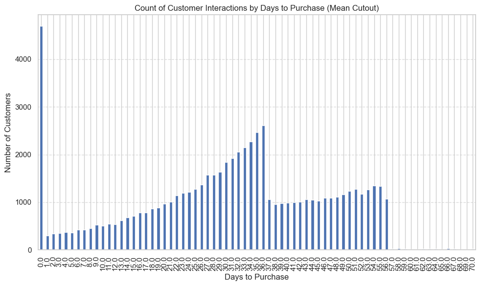

```python
# Plot
plt.figure(figsize=(10, 6))
interaction_count_by_days.plot(kind='bar')

plt.title('Count of Customer Interactions by Days to Purchase (Mean Cutout)')
plt.xlabel('Days to Purchase')
plt.ylabel('Number of Customers')
plt.xticks(rotation=90)
plt.grid(axis='y', linestyle='--', alpha=0.7)
plt.tight_layout()

plt.show()
```

##### **Take-7**

```python
# Investigate visit respect to gender

# Check whether all customer_id in visit_df is in users_df
visits_customer_id = pd.Series(visits_df["customer_id"].unique())
users_customer_id = pd.Series(users_df["customer_id"])

visited_and_in_users = visits_customer_id.isin(users_customer_id).sum()

print(visited_and_in_users == len(visits_customer_id))
```

```
True
```

- All "customer_id" values in "visits_df" also exist in "user_df".

```python
# Merge visits_df and users_df
visits_users_df = visits_df.merge(users_df, how="inner", on="customer_id")
visits_users_df.head()
```

|  | visit_id | customer_id | start_timestamp | end_timestamp | visit_type | transaction_id | visit_duration_min | is_purchase | interaction_count | first_purchase_time | days_to_purchase | user_first_name | user_last_name | gender | email |
| --- | --- | --- | --- | --- | --- | --- | --- | --- | --- | --- | --- | --- | --- | --- | --- |
| 0 | c631344d-6aed-4c7d-89e8-6835cb5ed2c9 | 00002fb6-1bad-48bf-ba4f-343fe4a2b31d | 2020-08-22 09:55:46.519489 | 2020-08-22 10:50:58.494331 | car configuration | NaN | 55.199581 | False | 1 | NaT | NaN | Heidi | Robinson | Female | heidi1993@gmail.com |
| 1 | 311907e3-1550-474f-93cc-8fb4a93a8e54 | 00002fb6-1bad-48bf-ba4f-343fe4a2b31d | 2023-07-21 09:32:33.393506 | 2023-07-21 10:27:35.380305 | viewing | NaN | 55.033113 | False | 2 | NaT | NaN | Heidi | Robinson | Female | heidi1993@gmail.com |
| 2 | e1b117f5-7463-4908-a5f3-8a5d692d7e90 | 00018dda-2d4b-4abb-8629-98a9063a5cba | 2021-04-21 11:04:49.301126 | 2021-04-21 11:08:49.301126 | viewing | NaN | 4.000000 | False | 1 | 2021-05-27 14:17:00 | 36.0 | Nathan | Murray | Male | murray@outlook.com |
| 3 | 5390836b-5ae1-448c-a13d-7ea43386b5d0 | 00018dda-2d4b-4abb-8629-98a9063a5cba | 2021-05-26 09:32:03.709773 | 2021-05-26 09:31:03.709773 | viewing | NaN | -1.000000 | False | 2 | 2021-05-27 14:17:00 | 1.0 | Nathan | Murray | Male | murray@outlook.com |
| 4 | f0f0023b-94a2-42c4-8c10-e2f595046ed1 | 00018dda-2d4b-4abb-8629-98a9063a5cba | 2021-05-27 14:17:00.000000 | 2021-05-27 14:37:00.000000 | purchasing | f2886883-c33e-4411-84d7-f137e7be11b2 | 20.000000 | True | 3 | 2021-05-27 14:17:00 | 0.0 | Nathan | Murray | Male | murray@outlook.com |

```python
# Quarterly how different gender categories interacts with website
visits_users_df['year_quarter'] = visits_users_df['start_timestamp'].dt.to_period('Q')

gender_quarterly_usage = visits_users_df.groupby(['year_quarter', 'gender'])['customer_id'].nunique().reset_index()
gender_quarterly_usage = gender_quarterly_usage.pivot(index='year_quarter', columns='gender', values='customer_id').fillna(0)
gender_quarterly_usage['total'] = gender_quarterly_usage.sum(axis=1)
gender_quarterly_usage
```

| gender year_quarter | Female | Male | Other | total |
| --- | --- | --- | --- | --- |
| 2020Q2 | 103 | 78 | 9 | 190 |
| 2020Q3 | 2849 | 2732 | 243 | 5824 |
| 2020Q4 | 4426 | 4159 | 358 | 8943 |
| 2021Q1 | 4776 | 4719 | 402 | 9897 |
| 2021Q2 | 5433 | 5235 | 419 | 11087 |
| 2021Q3 | 5895 | 5816 | 451 | 12162 |
| 2021Q4 | 6491 | 6434 | 543 | 13468 |
| 2022Q1 | 6956 | 6811 | 546 | 14313 |
| 2022Q2 | 7568 | 7684 | 626 | 15878 |
| 2022Q3 | 8433 | 8414 | 649 | 17496 |
| 2022Q4 | 9209 | 9184 | 724 | 19117 |
| 2023Q1 | 9948 | 10020 | 783 | 20751 |
| 2023Q2 | 11340 | 11305 | 920 | 23565 |
| 2023Q3 | 13099 | 12882 | 1083 | 27064 |
| 2023Q4 | 15848 | 15897 | 1322 | 33067 |
| 2024Q1 | 7497 | 7574 | 650 | 15721 |

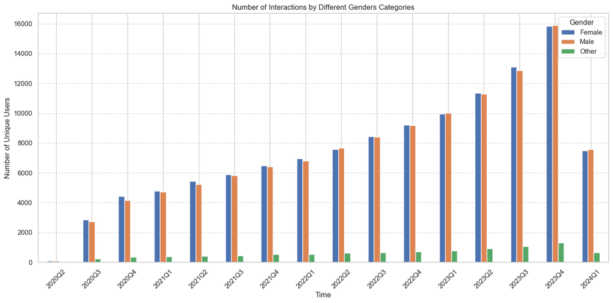

```python
# Plot
fig, ax = plt.subplots(figsize=(14, 7))
gender_quarterly_usage[gender_quarterly_usage.columns[:-1]].plot(kind='bar', ax=ax)

ax.set_title('Number of Interactions by Different Genders Categories')
ax.set_xlabel('Time')
ax.set_ylabel('Number of Unique Users')
ax.legend(title='Gender')

plt.xticks(rotation=45)
plt.grid(axis='y', linestyle='--', alpha=0.7)
plt.tight_layout()
plt.show()
```

```python
# Group by year_quarter, gender, and visit_type, then count the number of visits
gender_visit_type = visits_users_df.groupby(['year_quarter', 'gender', 'visit_type']).size().reset_index(name='count')
gender_visit_type_df = gender_visit_type.pivot_table(index='year_quarter', columns=['gender', 'visit_type'], values='count', fill_value=0)
gender_visit_type_df
```

| gender visit_type year_quarter | Female car configuration | Female purchasing | Female testing | Female viewing | Male car configuration | Male purchasing | Male testing | Male viewing | Other car configuration | Other purchasing | Other testing | Other viewing |
| --- | --- | --- | --- | --- | --- | --- | --- | --- | --- | --- | --- | --- |
| 2020Q2 | 2.0 | 0.0 | 99.0 | 5.0 | 2.0 | 0.0 | 72.0 | 6.0 | 0.0 | 0.0 | 8.0 | 1.0 |
| 2020Q3 | 411.0 | 851.0 | 2342.0 | 2399.0 | 417.0 | 822.0 | 2209.0 | 2366.0 | 34.0 | 70.0 | 188.0 | 189.0 |
| 2020Q4 | 778.0 | 2012.0 | 2773.0 | 3962.0 | 702.0 | 1858.0 | 2665.0 | 3563.0 | 82.0 | 178.0 | 208.0 | 340.0 |
| 2021Q1 | 998.0 | 2064.0 | 2562.0 | 4260.0 | 955.0 | 2057.0 | 2695.0 | 4094.0 | 80.0 | 167.0 | 219.0 | 373.0 |
| 2021Q2 | 1160.0 | 2257.0 | 2784.0 | 4767.0 | 1121.0 | 2222.0 | 2673.0 | 4690.0 | 92.0 | 179.0 | 207.0 | 425.0 |
| 2021Q3 | 1412.0 | 2317.0 | 2786.0 | 5168.0 | 1439.0 | 2326.0 | 2629.0 | 5267.0 | 106.0 | 186.0 | 193.0 | 411.0 |
| 2021Q4 | 1567.0 | 2512.0 | 2796.0 | 5932.0 | 1569.0 | 2521.0 | 2710.0 | 5864.0 | 149.0 | 195.0 | 229.0 | 500.0 |
| 2022Q1 | 1789.0 | 2519.0 | 2818.0 | 6025.0 | 1733.0 | 2464.0 | 2697.0 | 6044.0 | 137.0 | 198.0 | 223.0 | 467.0 |
| 2022Q2 | 2137.0 | 2609.0 | 2811.0 | 6754.0 | 2146.0 | 2666.0 | 2779.0 | 6997.0 | 144.0 | 211.0 | 254.0 | 561.0 |
| 2022Q3 | 2467.0 | 2728.0 | 2834.0 | 7356.0 | 2467.0 | 2800.0 | 2788.0 | 7401.0 | 156.0 | 223.0 | 221.0 | 596.0 |
| 2022Q4 | 2708.0 | 2965.0 | 3055.0 | 8130.0 | 2789.0 | 2867.0 | 2775.0 | 8090.0 | 198.0 | 220.0 | 204.0 | 638.0 |
| 2023Q1 | 3046.0 | 2863.0 | 2807.0 | 8813.0 | 3069.0 | 2924.0 | 2880.0 | 8858.0 | 247.0 | 211.0 | 233.0 | 664.0 |
| 2023Q2 | 3755.0 | 3023.0 | 2840.0 | 9864.0 | 3653.0 | 3083.0 | 2776.0 | 9666.0 | 296.0 | 250.0 | 246.0 | 801.0 |
| 2023Q3 | 4321.0 | 3189.0 | 2857.0 | 11364.0 | 4294.0 | 3112.0 | 2896.0 | 11211.0 | 396.0 | 250.0 | 231.0 | 901.0 |
| 2023Q4 | 5725.0 | 3350.0 | 2834.0 | 13349.0 | 5580.0 | 3320.0 | 2905.0 | 13646.0 | 503.0 | 304.0 | 215.0 | 1187.0 |
| 2024Q1 | 2344.0 | 1062.0 | 620.0 | 4840.0 | 2459.0 | 1132.0 | 619.0 | 4826.0 | 212.0 | 85.0 | 44.0 | 421.0 |

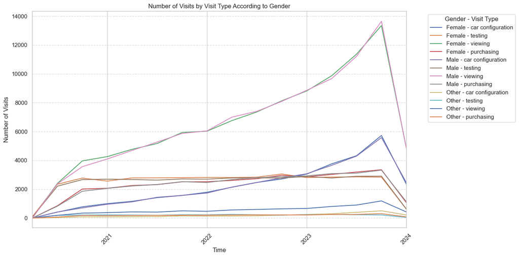

```python
# Plot
fig, ax = plt.subplots(figsize=(14, 7))

for gender in gender_visit_type['gender'].unique():
    for visit_type in gender_visit_type['visit_type'].unique():
        gender_visit_type_df[(gender, visit_type)].plot(ax=ax, label=f'{gender} - {visit_type}')


ax.set_title('Number of Visits by Visit Type According to Gender')
ax.set_xlabel('Time')
ax.set_ylabel('Number of Visits')

plt.xticks(rotation=45)
plt.grid(axis='y', linestyle='--', alpha=0.7)
plt.legend(title='Gender - Visit Type', bbox_to_anchor=(1.05, 1), loc='upper left')
plt.tight_layout()
plt.show()
```

##### **Take-8**

- Different gender categories (Female, Male, Other) show similar trends in terms of visits to the website. When examining different visit types, the trends are also similar.
- Since the counts of females and males are similar, both the number of visits and the visits by different visit types are quite similar.
- Although the "Other" gender category seems to be significantly behind the female and male categories, it follows its population characteristics (only 4.0%).
- Therefore, gender category does not affect the number of interactions or the number of interactions by visit types.

#### **Sales Dataset**

```python
# Load dataset and display
sales_df = pd.read_csv("./data/sales.csv")
sales_df.head()
```

|  | transaction_id | customer_id | car_id | platform | purchase_date | purchase_price | user_review |
| --- | --- | --- | --- | --- | --- | --- | --- |
| 0 | d8ea7895-4dda-4419-9291-5fe446c8d387 | d4a436e4-938c-4281-9c9c-5912be025b19 | 5fae80e1-82d6-45d3-8512-7db7bb32d5bd | Website | 2021-10-14 | 45000.0 | NaN |
| 1 | 73bba083-92ea-4580-80ef-527193c8a897 | 1105c980-82a0-4296-8de0-fcb37fbdd435 | eee54c45-64fe-462b-b9c2-e23adea76282 | Dealership | 2022-11-03 | 30000.0 | NaN |
| 2 | 4150e505-a55e-4eb8-b321-92ed2e96553e | 8c987376-6996-4137-977a-5415b81b55d0 | ab72e1ef-639f-4ad0-b9b0-28a50f3c7229 | Website | 2023-12-14 | 131000.0 | NaN |
| 3 | 5bf1dbeb-6469-4b77-accd-4af5ce6a48a2 | 9289286a-dece-4d9c-9d64-fafd949f7fb0 | 0c048ea4-5e29-419e-a448-99f75742117c | Dealership | 2023-02-14 | 70000.0 | NaN |
| 4 | e7e61ff9-0ac3-4101-b195-369faa256f79 | ba30d504-d66f-4879-8af3-999884f2e0f8 | eee54c45-64fe-462b-b9c2-e23adea76282 | Dealership | 2022-07-04 | 30000.0 | 1.0 |

```python
# Details about users_df
num_entities = sales_df.shape[0]
num_columns = sales_df.shape[1]
column_names = list(sales_df.columns)

print(f"The dataset contains {num_entities} entities, each with {num_columns} attributes.\nThe column names are: {column_names}")
```

```
The dataset contains 74836 entities, each with 7 attributes.
The column names are: ['transaction_id', 'customer_id', 'car_id', 'platform', 'purchase_date', 'purchase_price', 'user_review']
```

```python
# The data types in users_df
sales_df.dtypes
```

```
transaction_id     object
customer_id        object
car_id             object
platform           object
purchase_date      object
purchase_price    float64
user_review       float64
dtype: object
```

```python
# Convert purchase_date column to datetime
sales_df["purchase_date"] = sales_df["purchase_date"].apply(lambda x: pd.to_datetime(x))
sales_df.dtypes
```

```
transaction_id            object
customer_id               object
car_id                    object
platform                  object
purchase_date     datetime64[ns]
purchase_price           float64
user_review              float64
dtype: object
```

```python
# Check for the presence of null entities
sales_df.isnull().sum()
```

```
transaction_id       24
customer_id          24
car_id                0
platform              0
purchase_date         0
purchase_price       32
user_review       65070
dtype: int64
```

```python
# Drop Nan values in customer_id since it is unique and use as id for customers
sales_df.dropna(subset=["transaction_id"], inplace = True)
sales_df.isnull().sum()
```

```
transaction_id        0
customer_id          16
car_id                0
platform              0
purchase_date         0
purchase_price       32
user_review       65070
dtype: int64
```

```python
# Check validity of transaction_id
transaction_id_pattern = r'^[0-9a-f]{8}-[0-9a-f]{4}-[0-9a-f]{4}-[0-9a-f]{4}-[0-9a-f]{12}$'

sales_df['transaction_id'].astype(str).str.match(transaction_id_pattern).all()
```

```
True
```

- It is important to check the first and last sale because some of the car models could be outside of this span.

```python
# What is the earliest sales on the data and latest
print("First sale: ", sales_df["purchase_date"].min())
print("Last sale: ", sales_df["purchase_date"].max())
```

```
First sale:  2020-08-19 00:00:00
Last sale:  2024-01-30 00:00:00
```

```python
# How many different platfort exist in the data
platforms = sales_df["platform"].value_counts()
platforms
```

```
platform
Dealership    36306
Mobile App    23947
Website       14559
Name: count, dtype: int64
```

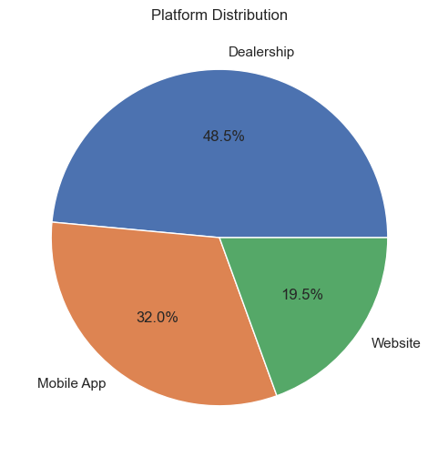

```python
# Plot
plt.figure(figsize=(6,6))

platforms.plot(kind="pie", autopct="%1.1f%%")

plt.title("Platform Distribution")
plt.ylabel("")
plt.show()
```

##### **Take-1**

```python
# Investigate sales trends quarterly
quarterly_purchases = sales_df.set_index('purchase_date')

quarterly_purchases = quarterly_purchases.resample('Q')["transaction_id"].count()
quarterly_purchases.index = quarterly_purchases.index.to_period('Q')
quarterly_purchases
```

```
purchase_date
2020Q3    1737
2020Q4    4024
2021Q1    4253
2021Q2    4627
2021Q3    4787
2021Q4    5179
2022Q1    5145
2022Q2    5445
2022Q3    5702
2022Q4    6003
2023Q1    5933
2023Q2    6307
2023Q3    6493
2023Q4    6919
2024Q1    2258
Freq: Q-DEC, Name: transaction_id, dtype: int64
```

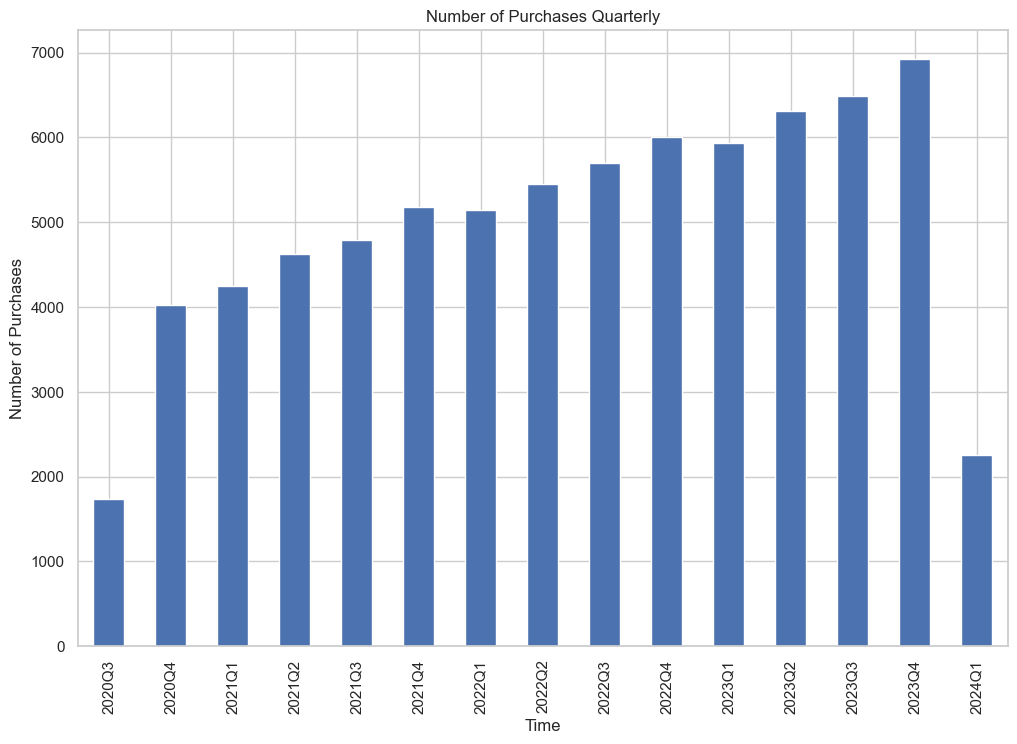

```python
# Plot
fig, ax = plt.subplots(figsize=(12, 8))
ax.set_xticklabels([str(period) for period in quarterly_purchases.index])

quarterly_purchases.plot(kind='bar')

plt.title('Number of Purchases Quarterly')
plt.xlabel('Time')
plt.ylabel('Number of Purchases')
plt.show()
```

```python
# Also look at revenue quarterly
quarterly_revenue = sales_df.set_index('purchase_date')
quarterly_revenue = quarterly_revenue.resample('Q')['purchase_price'].sum()
quarterly_revenue.index = quarterly_revenue.index.to_period('Q')
quarterly_revenue
```

```
purchase_date
2020Q3    1.102590e+08
2020Q4    2.513577e+08
2021Q1    2.691770e+08
2021Q2    2.988101e+08
2021Q3    3.137810e+08
2021Q4    3.457543e+08
2022Q1    3.458090e+08
2022Q2    3.703550e+08
2022Q3    3.909090e+08
2022Q4    4.197169e+08
2023Q1    4.190590e+08
2023Q2    4.491782e+08
2023Q3    4.778860e+08
2023Q4    5.072468e+08
2024Q1    1.656080e+08
Freq: Q-DEC, Name: purchase_price, dtype: float64
```

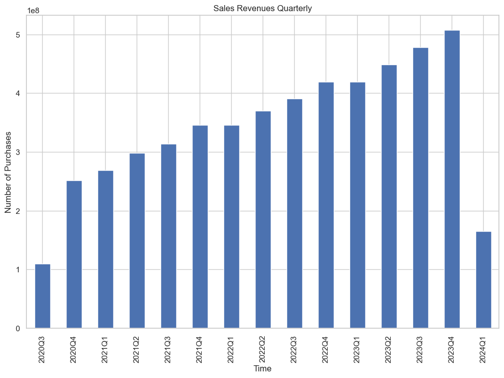

```python
# Plot
fig, ax = plt.subplots(figsize=(12, 8))
ax.set_xticklabels([str(period) for period in quarterly_revenue.index])

quarterly_revenue.plot(kind='bar')

plt.title('Sales Revenues Quarterly')
plt.xlabel('Time')
plt.ylabel('Number of Purchases')
plt.show()
```

```python
# Investigate quarterly sales by platform
quarterly_platform = sales_df.set_index('purchase_date')
quarterly_platform = quarterly_platform.groupby('platform').resample('Q')['transaction_id'].count().unstack('platform', fill_value=0)
quarterly_platform.index = quarterly_platform.index.to_period('Q')
quarterly_platform
```

| platform purchase_date | Dealership | Mobile App | Website |
| --- | --- | --- | --- |
| 2020Q3 | 1081 | 403 | 253 |
| 2020Q4 | 2497 | 963 | 564 |
| 2021Q1 | 2401 | 1233 | 619 |
| 2021Q2 | 2499 | 1429 | 699 |
| 2021Q3 | 2478 | 1560 | 749 |
| 2021Q4 | 2619 | 1723 | 837 |
| 2022Q1 | 2553 | 1719 | 873 |
| 2022Q2 | 2616 | 1852 | 977 |
| 2022Q3 | 2664 | 1962 | 1076 |
| 2022Q4 | 2791 | 1975 | 1237 |
| 2023Q1 | 2673 | 1989 | 1271 |
| 2023Q2 | 2806 | 2068 | 1433 |
| 2023Q3 | 2731 | 2146 | 1616 |
| 2023Q4 | 2943 | 2213 | 1763 |
| 2024Q1 | 954 | 712 | 592 |

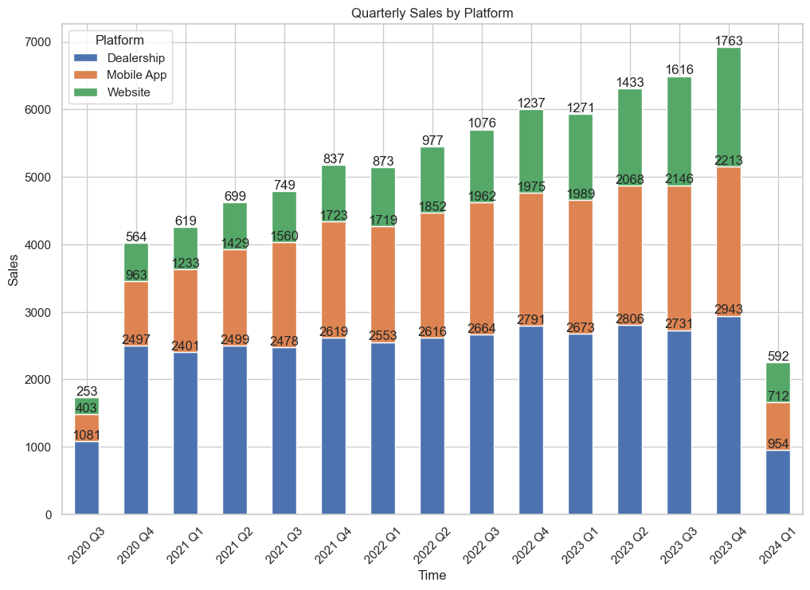

```python
# Plot
fig, ax = plt.subplots(figsize=(12, 8))
x_labels = [f'{idx.year} Q{idx.quarter}' for idx in quarterly_platform.index]

quarterly_platform.plot(kind='bar', stacked=True, ax=ax)

plt.title('Quarterly Sales by Platform')
plt.xlabel('Time')
plt.ylabel('Sales')
plt.xticks(ticks=range(len(x_labels)), labels=x_labels, rotation=45)
plt.legend(title='Platform')

for p in ax.patches:
    height = p.get_height()
    if height > 0:
        ax.annotate(f'{height:.0f}', (p.get_x() + p.get_width() / 2., p.get_y() + height),
                    ha='center', va='center', xytext=(0, 5), textcoords='offset points')

plt.show()
```

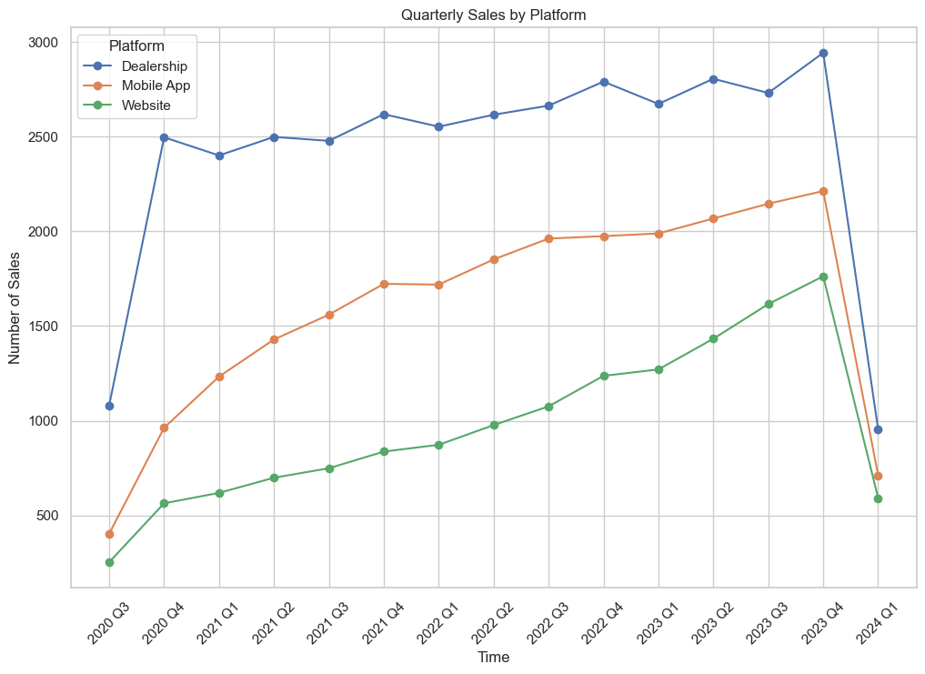

```python
# Plot to undestand trend
fig, ax = plt.subplots(figsize=(12, 8))
x_labels = [f'{idx.year} Q{idx.quarter}' for idx in quarterly_platform.index]

platforms = quarterly_platform.columns

for i, platform in enumerate(platforms):
    ax.plot(x_labels, quarterly_platform[platform], 'o-', label=platform)

plt.title('Quarterly Sales by Platform')
plt.xlabel('Time')
plt.ylabel('Number of Sales')
plt.xticks(rotation=45)
plt.legend(title='Platform')
plt.show()
```

```python
# Investigate quarterly revenue by platform
quarterly_platform_revenue = sales_df.set_index('purchase_date')
quarterly_platform_revenue = quarterly_platform_revenue.groupby('platform').resample('Q')['purchase_price'].sum().unstack('platform', fill_value=0)
quarterly_platform_revenue.index = quarterly_platform_revenue.index.to_period('Q')
quarterly_platform_revenue
```

| platform purchase_date | Dealership | Mobile App | Website |
| --- | --- | --- | --- |
| 2020Q3 | 5.581000e+07 | 2.514100e+07 | 2.930800e+07 |
| 2020Q4 | 1.270095e+08 | 5.778062e+07 | 6.656757e+07 |
| 2021Q1 | 1.230450e+08 | 7.512500e+07 | 7.100700e+07 |
| 2021Q2 | 1.290461e+08 | 8.913149e+07 | 8.063250e+07 |
| 2021Q3 | 1.270460e+08 | 9.979300e+07 | 8.694200e+07 |
| 2021Q4 | 1.356555e+08 | 1.100539e+08 | 1.000449e+08 |
| 2022Q1 | 1.310490e+08 | 1.102910e+08 | 1.044690e+08 |
| 2022Q2 | 1.354584e+08 | 1.181526e+08 | 1.167440e+08 |
| 2022Q3 | 1.374390e+08 | 1.243780e+08 | 1.290920e+08 |
| 2022Q4 | 1.433664e+08 | 1.278972e+08 | 1.484532e+08 |
| 2023Q1 | 1.382870e+08 | 1.269810e+08 | 1.537910e+08 |
| 2023Q2 | 1.444461e+08 | 1.306697e+08 | 1.740624e+08 |
| 2023Q3 | 1.446510e+08 | 1.383300e+08 | 1.949050e+08 |
| 2023Q4 | 1.528299e+08 | 1.414465e+08 | 2.129704e+08 |
| 2024Q1 | 4.770800e+07 | 4.544000e+07 | 7.246000e+07 |

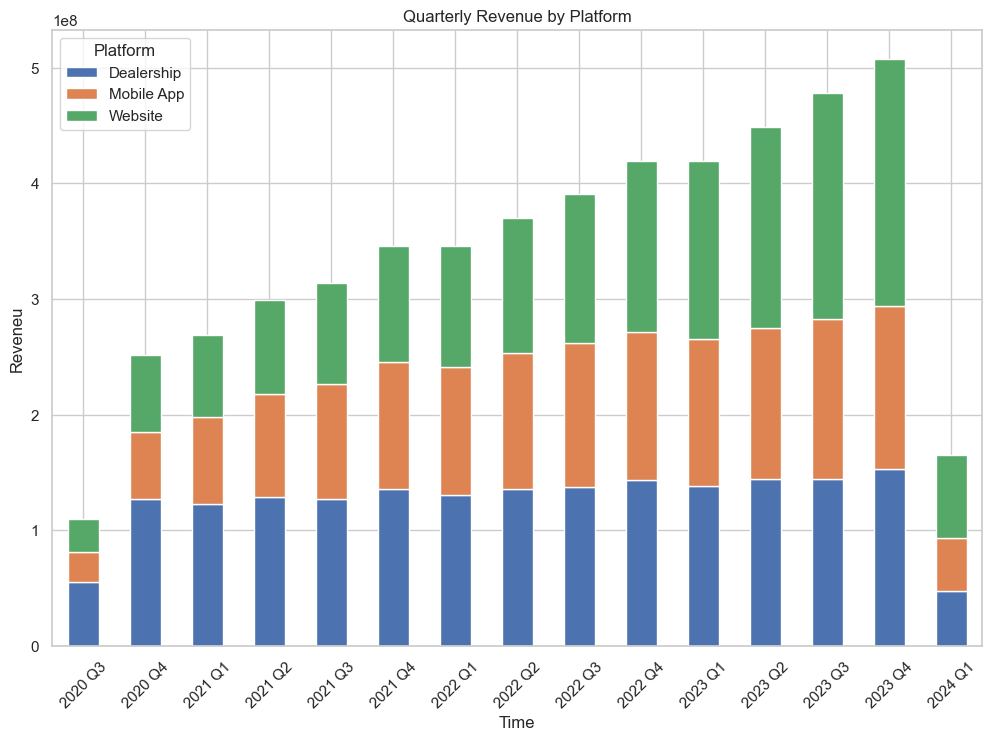

```python
# Plot
fig, ax = plt.subplots(figsize=(12, 8))
x_labels = [f'{idx.year} Q{idx.quarter}' for idx in quarterly_platform_revenue.index]

quarterly_platform_revenue.plot(kind='bar', stacked=True, ax=ax)

plt.title('Quarterly Revenue by Platform')
plt.xlabel('Time')
plt.ylabel('Reveneu')
plt.xticks(ticks=range(len(x_labels)), labels=x_labels, rotation=45)
plt.legend(title='Platform')
plt.show()
```

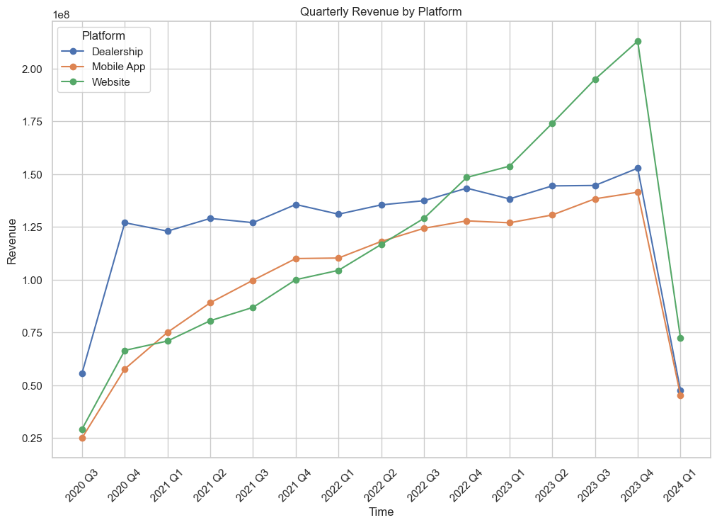

```python
# Plot to undestand trend
fig, ax = plt.subplots(figsize=(12, 8))
x_labels = [f'{idx.year} Q{idx.quarter}' for idx in quarterly_platform_revenue.index]

platforms = quarterly_platform_revenue.columns

for i, platform in enumerate(platforms):
    ax.plot(x_labels, quarterly_platform_revenue[platform], 'o-', label=platform)

plt.title('Quarterly Revenue by Platform')
plt.xlabel('Time')
plt.ylabel('Revenue')
plt.xticks(rotation=45)
plt.legend(title='Platform')
plt.show()
```

```python
# Overall revenue by platform
platform_revenue = sales_df.set_index('purchase_date')
platform_revenue = platform_revenue.groupby('platform')['purchase_price'].sum()
platform_revenue
```

```
platform
Dealership    1.872847e+09
Mobile App    1.520611e+09
Website       1.741449e+09
Name: purchase_price, dtype: float64
```

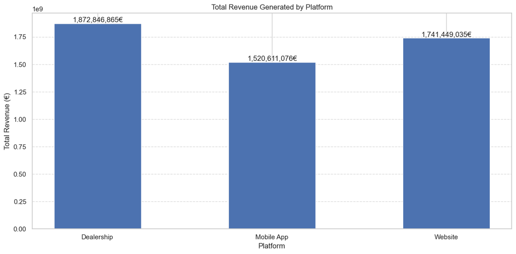

```python
# Plot
plt.figure(figsize=(12, 6))

num_platforms = len(platform_revenue.index)
bar_width = 0.5
index = np.arange(len(platform_revenue.index))
bars = plt.bar(index, platform_revenue, bar_width)

for bar in bars:
    height = bar.get_height()
    plt.text(bar.get_x() + bar.get_width() / 2, height, f'{height:,.0f}€', ha='center', va='bottom')

plt.title('Total Revenue Generated by Platform')
plt.xlabel('Platform')
plt.ylabel('Total Revenue (€)')
plt.xticks(index, platform_revenue.index)
plt.grid(axis='y', linestyle='--', alpha=0.7)
plt.tight_layout()
plt.show()
```

##### **Take-2**

- As time passes, the number of sales and the revenue generated by sales increased.
- This increase is mostly driven by the sales increase in the "Website" and "Mobile App" platforms. It's also worth noting that sales in "Dealership" have increased, but this increase is smaller compared to other platforms. Overall, the dealership is the platform that made the most sales, followed by the Mobile App and Website, respectively.
- One of the most important takeaways is that these increases in different platforms also translate to revenue. At the beginning of 2020 Q3, the dealership was the most revenue-generating platform. However, by 2024 Q1, the Website platform took over, and it is now the most revenue-generating platform, even though it has the smallest number of sales.
- However, over the entire time span, the "Dealership" platform remains the most revenue-generating platform, followed by the "Website" and the "Mobile App."
- This might indicate that although the Website platform made the smallest number of sales, it is selling more expensive cars compared to other channels.

```python
avg_car_price_platform = sales_df.set_index('purchase_date')
avg_car_price_platform =  (avg_car_price_platform.groupby('platform').resample('Q')['purchase_price'].sum() /
                          avg_car_price_platform.groupby('platform').resample('Q')['transaction_id'].count()).unstack('platform', fill_value=0)
avg_car_price_platform
```

| platform purchase_date | Dealership | Mobile App | Website |
| --- | --- | --- | --- |
| 2020-09-30 | 51628.122109 | 62384.615385 | 115841.897233 |
| 2020-12-31 | 50864.846495 | 60000.641127 | 118027.614514 |
| 2021-03-31 | 51247.396918 | 60928.629359 | 114712.439418 |
| 2021-06-30 | 51639.106518 | 62373.331473 | 115354.072493 |
| 2021-09-30 | 51269.572236 | 63969.871795 | 116077.436582 |
| 2021-12-31 | 51796.662911 | 63873.444422 | 119527.933389 |
| 2022-03-31 | 51331.374853 | 64159.976731 | 119666.666667 |
| 2022-06-30 | 51780.725033 | 63797.310334 | 119492.359799 |
| 2022-09-30 | 51591.216216 | 63393.476045 | 119973.977695 |
| 2022-12-31 | 51367.394505 | 64758.091788 | 120010.694046 |
| 2023-03-31 | 51734.754957 | 63841.628959 | 121000.000000 |
| 2023-06-30 | 51477.590458 | 63186.503751 | 121467.132206 |
| 2023-09-30 | 52966.312706 | 64459.459459 | 120609.529703 |
| 2023-12-31 | 51929.956778 | 63916.169792 | 120800.010720 |
| 2024-03-31 | 50008.385744 | 63820.224719 | 122398.648649 |

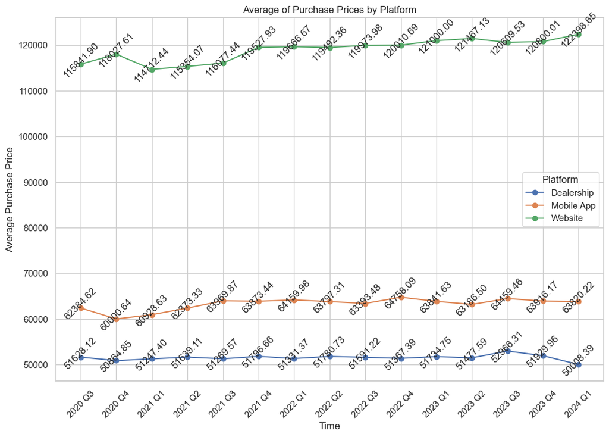

```python
# Plot
fig, ax = plt.subplots(figsize=(12, 8))
x_labels = [f'{idx.year} Q{idx.quarter}' for idx in avg_car_price_platform.index]

platforms = avg_car_price_platform.columns

for i, platform in enumerate(platforms):
    ax.plot(x_labels, avg_car_price_platform[platform], 'o-', label=platform)

plt.title('Average of Purchase Prices by Platform')
plt.xlabel('Time')
plt.ylabel('Average Purchase Price')
plt.xticks(rotation=45)
plt.legend(title='Platform')

for i, platform in enumerate(platforms):
    for j, value in enumerate(avg_car_price_platform[platform]):
        if value > 0:
            ax.annotate(f'{value:.2f}', (j, value),
                        ha='center', va='center', xytext=(0, 5), textcoords='offset points', rotation=45)

plt.show()
```

##### **Take-3**

- Our guess about the "Website" platform being the platform that sells the most expensive cars is verified by the above plot. Furthermore, the Mobile App platform follows, and then the Dealership platform sells the cheapest cars.
- Also, comparing this plot with our insights from the Cars Dataset, we can also infer that the Dealership and the Mobile App mostly sells Gasoline and Diesel Cars, and the Website mostly sells Electric Cars, which will be verified later.

```python
sales_cars_df = sales_df.merge(cars_df, on="car_id", how="left")
sales_cars_df.head()
```

|  | transaction_id | customer_id | car_id | platform | purchase_date | purchase_price | user_review | car_model | fuel_type | release_date | price |
| --- | --- | --- | --- | --- | --- | --- | --- | --- | --- | --- | --- |
| 0 | d8ea7895-4dda-4419-9291-5fe446c8d387 | d4a436e4-938c-4281-9c9c-5912be025b19 | 5fae80e1-82d6-45d3-8512-7db7bb32d5bd | Website | 2021-10-14 | 45000.0 | NaN | Sedan | Gasoline | 2018-07-15 | 45000 |
| 1 | 73bba083-92ea-4580-80ef-527193c8a897 | 1105c980-82a0-4296-8de0-fcb37fbdd435 | eee54c45-64fe-462b-b9c2-e23adea76282 | Dealership | 2022-11-03 | 30000.0 | NaN | 1 Series | Diesel | 2010-10-01 | 30000 |
| 2 | 4150e505-a55e-4eb8-b321-92ed2e96553e | 8c987376-6996-4137-977a-5415b81b55d0 | ab72e1ef-639f-4ad0-b9b0-28a50f3c7229 | Website | 2023-12-14 | 131000.0 | NaN | Model iX | Electric | 2017-11-10 | 131000 |
| 3 | 5bf1dbeb-6469-4b77-accd-4af5ce6a48a2 | 9289286a-dece-4d9c-9d64-fafd949f7fb0 | 0c048ea4-5e29-419e-a448-99f75742117c | Dealership | 2023-02-14 | 70000.0 | NaN | Model M | Gasoline | 2016-04-01 | 70000 |
| 4 | e7e61ff9-0ac3-4101-b195-369faa256f79 | ba30d504-d66f-4879-8af3-999884f2e0f8 | eee54c45-64fe-462b-b9c2-e23adea76282 | Dealership | 2022-07-04 | 30000.0 | 1.0 | 1 Series | Diesel | 2010-10-01 | 30000 |

```python
# Number of sales in platform by fuel type
fuel_type_counts = sales_cars_df.groupby(['platform', 'fuel_type']).size().unstack(fill_value=0)
fuel_type_counts
```

| fuel_type platform | Diesel | Electric | Gasoline |
| --- | --- | --- | --- |
| Dealership | 23026 | 5686 | 7594 |
| Mobile App | 10203 | 5719 | 8025 |
| Website | 1300 | 11036 | 2223 |

```python
# Look Overall Sales
fuel_type_counts.sum()
```

```
fuel_type
Diesel      34529
Electric    22441
Gasoline    17842
dtype: int64
```

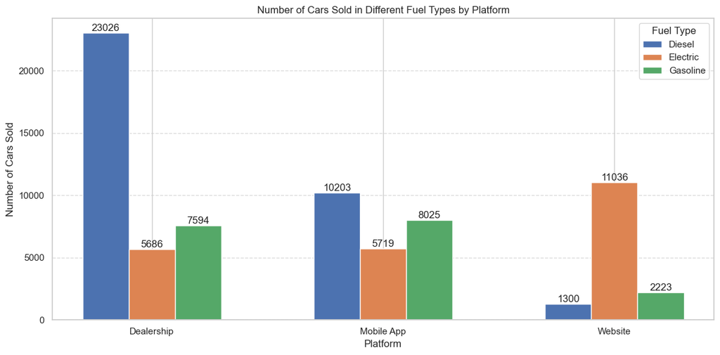

```python
# Plot
plt.figure(figsize=(12, 6))

num_fuel_types = len(fuel_type_counts.columns)
bar_width = 0.2
index = np.arange(len(fuel_type_counts.index))

for i, fuel_type in enumerate(fuel_type_counts.columns):
    plt.bar(index + i * bar_width, fuel_type_counts[fuel_type], bar_width, label=fuel_type)
    for j, value in enumerate(fuel_type_counts[fuel_type]):
        plt.text(index[j] + i * bar_width, value + 0.2, str(value), ha='center', va='bottom')

plt.title('Number of Cars Sold in Different Fuel Types by Platform')
plt.xlabel('Platform')
plt.ylabel('Number of Cars Sold')
plt.xticks(index + bar_width * (num_fuel_types - 1) / 2, fuel_type_counts.index)
plt.legend(title='Fuel Type')
plt.grid(axis='y', linestyle='--', alpha=0.7)
plt.tight_layout()
plt.show()
```

```python
# Revenue by fuel type
fuel_type_revenue = sales_cars_df.set_index('purchase_date')
fuel_type_revenue = fuel_type_revenue.groupby('fuel_type')['purchase_price'].sum()
fuel_type_revenue
```

```
fuel_type
Diesel      1.091315e+09
Electric    2.869516e+09
Gasoline    1.174076e+09
Name: purchase_price, dtype: float64
```

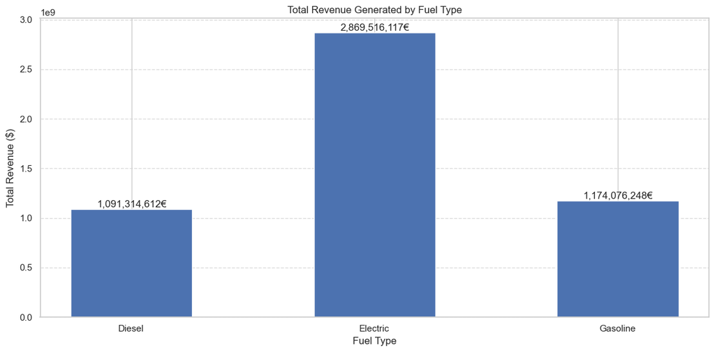

```python
# Plot
plt.figure(figsize=(12, 6))

num_fuel_types = len(fuel_type_revenue.index)
bar_width = 0.5
index = np.arange(len(fuel_type_revenue.index))
bars = plt.bar(index, fuel_type_revenue, bar_width)

for bar in bars:
    height = bar.get_height()
    plt.text(bar.get_x() + bar.get_width() / 2, height, f'{height:,.0f}€', ha='center', va='bottom')

plt.title('Total Revenue Generated by Fuel Type')
plt.xlabel('Fuel Type')
plt.ylabel('Total Revenue ($)')
plt.xticks(index, fuel_type_revenue.index)
plt.grid(axis='y', linestyle='--', alpha=0.7)
plt.tight_layout()
plt.show()
```

##### **Take-4**

```python
# Sales by car models and fuel_type
car_fuel_counts = sales_cars_df.set_index('purchase_date')
car_fuel_counts = car_fuel_counts.groupby(['car_model', 'fuel_type']).size().unstack(fill_value=0)
car_fuel_counts
```

| fuel_type car_model | Diesel | Electric | Gasoline |
| --- | --- | --- | --- |
| 1 Series | 26947 | 0 | 0 |
| 3 Series | 3760 | 0 | 0 |
| Coupe | 0 | 0 | 3448 |
| Model M | 0 | 0 | 3464 |
| Model i7 | 0 | 3264 | 0 |
| Model i8 | 0 | 12458 | 0 |
| Model iX | 0 | 3242 | 0 |
| Model iY | 0 | 3477 | 0 |
| Sedan | 0 | 0 | 3717 |
| Sierra | 3822 | 0 | 0 |
| Tourer | 0 | 0 | 3573 |
| Touring | 0 | 0 | 3640 |

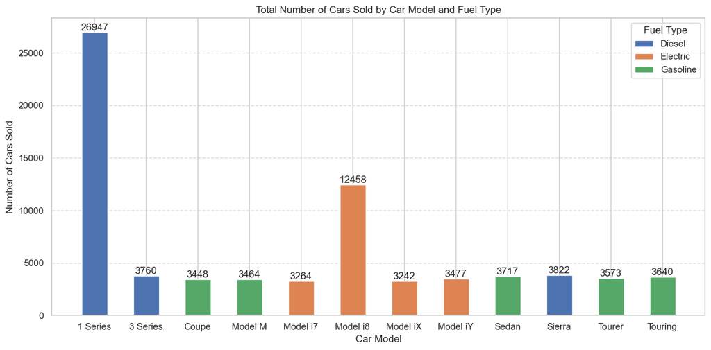

```python
# Plot
plt.figure(figsize=(12, 6))

num_models = len(car_fuel_counts.index)
bar_width = 0.5
index = np.arange(len(car_fuel_counts.index))

for i, fuel_type in enumerate(car_fuel_counts.columns):
    plt.bar(index, car_fuel_counts[fuel_type], bar_width, label=fuel_type)

for i, value in enumerate(car_fuel_counts.index):
    plt.text(index[i], car_fuel_counts.iloc[i].sum() + 0.2, str(car_fuel_counts.iloc[i].sum()), ha='center', va='bottom')


plt.title('Total Number of Cars Sold by Car Model and Fuel Type')
plt.xlabel('Car Model')
plt.ylabel('Number of Cars Sold')
plt.xticks(index, car_fuel_counts.index)
plt.legend(title='Fuel Type')
plt.grid(axis='y', linestyle='--', alpha=0.7)
plt.tight_layout()
plt.show()
```

```python
# Sales of car models by platform
car_model_plaftorm = sales_cars_df.set_index('purchase_date')
car_model_plaftorm = car_model_plaftorm.groupby(['platform', 'car_model']).size().unstack(fill_value=0)
car_model_plaftorm
```

| car_model platform | 1 Series | 3 Series | Coupe | Model M | Model i7 | Model i8 | Model iX | Model iY | Sedan | Sierra | Tourer | Touring |
| --- | --- | --- | --- | --- | --- | --- | --- | --- | --- | --- | --- | --- |
| Dealership | 19773 | 1602 | 1505 | 1498 | 1424 | 1336 | 1424 | 1502 | 1559 | 1651 | 1520 | 1512 |
| Mobile App | 6701 | 1739 | 1565 | 1590 | 1439 | 1429 | 1370 | 1481 | 1684 | 1763 | 1659 | 1527 |
| Website | 473 | 419 | 378 | 376 | 401 | 9693 | 448 | 494 | 474 | 408 | 394 | 601 |

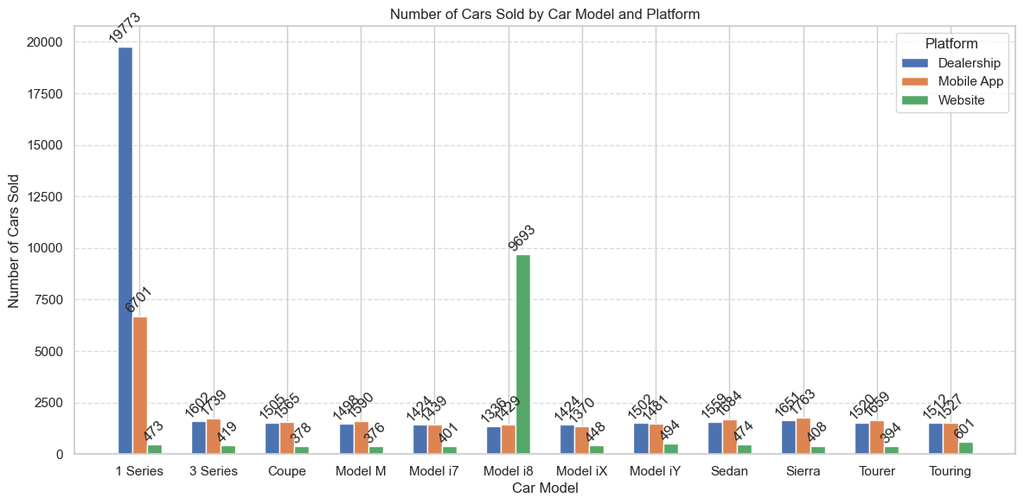

```python
# Plot
plt.figure(figsize=(12, 6))

num_models = len(car_model_plaftorm.index)
bar_width = 0.2
index = np.arange(len(car_model_plaftorm.columns))

for i, platform in enumerate(car_model_plaftorm.index):
    plt.bar(index + i * bar_width, car_model_plaftorm.loc[platform], bar_width, label=platform)
    for j, value in enumerate(car_model_plaftorm.loc[platform]):
        plt.text(index[j] + i * bar_width, value + 0.2, str(value), ha='center', va='bottom', rotation=45)

plt.title('Number of Cars Sold by Car Model and Platform')
plt.xlabel('Car Model')
plt.ylabel('Number of Cars Sold')
plt.xticks(index + bar_width * (num_models - 1) / 2, car_model_plaftorm.columns)
plt.legend(title='Platform')
plt.grid(axis='y', linestyle='--', alpha=0.7)
plt.tight_layout()
plt.show()
```